# PENPAL — Novelty, Transience, and Resonance (window-level, turn-agnostic)

Author

PENPAL Collaboration Team

Published

September 22, 2026

## 1. Theoretical Foundations & Corpus Setup

### 1.1 The Information-Theoretic Framework (Barron et al., 2018)

This analysis quantifies collaborative storytelling dynamics using information-theoretic measures of **Novelty ($N$)**, **Transience ($T$)**, and **Resonance ($R$)**, grounded in the foundational framework established by Barron, Huang, Spang, & DeDeo (2018; *PNAS*).

In an autoregressive causal language model, each token $w_t$ has an associated conditional probability $P(w_t \mid w_{<t})$ given the preceding context $w_{<t} = (w_1, \dots, w_{t-1})$. The **surprisal** (in bits, base-2 logarithm) is defined as:

$$S(w_t) = -\log_2 P(w_t \mid w_{<t})$$

Surprisal reflects unexpectedness: low surprisal denotes predictable, formulaic language conforming to the prior context, while high surprisal indicates novel vocabulary, sudden plot twists, or dramatic stylistic shifts.

Adapting the Barron et al. (2018) framework to sequential text generation: 1. **Novelty ($N$)**: Measures the informational departure of the current text window from the preceding narrative history. High novelty means the window introduces unexpected narrative elements not predicted by the story’s past. 2. **Transience ($T$)**: Measures how quickly the information introduced in the current window is abandoned or forgotten in subsequent text. High transience indicates that the innovation was fleeting and failed to take root. 3. **Resonance ($R = N - T$)**: Quantifies the lasting, durable impact of the current window on the ongoing narrative trajectory. A positive resonance ($R > 0$) signifies that the novel ideas were successfully retained, adopted, and integrated into subsequent discourse; a negative resonance ($R < 0$) indicates that the window was an ephemeral distraction that quickly faded away.

### 1.2 Unit of Analysis: Canonical Sentence Units & Length Control

To capture fine-grained narrative dynamics across the entire story artifact, the active pipeline evaluates **canonical sentence units** (`surprisal_unit_level.csv`, $N = 9,202$ units across $N = 320$ stories across all four conditions): - **Cross-Modal 1:1 Alignment**: Sentence segmentation is performed once via spaCy (`en_core_web_md`) and shared across the embedding trajectory, RQA, and surprisal pipelines (`sentence_index.csv`). Every sentence unit carries a universal `sent_idx` join key, allowing token-level predictive surprisal to be directly mapped to vector-space geometric excursions (`novelty_centroid`) and path detours (`path_detour`). - **Controlling for Sentence Length**: Because mean sentence length varies systematically by condition (Human–Human: $\sim 13.8$ words; Human–AI: $\sim 17.4$ words; AI–AI: $\sim 22.4$ words), all sentence-level mixed-effects models explicitly carry sentence word length (`n_unit_words`) as a fixed covariate. This eliminates the length confounds that previously compromised topic-KL models while preserving natural syntactic and semantic boundaries. - **Contrast with Fixed Sub-Turn Windows ($w = 14$)**: Earlier iterations evaluated fixed 14-word sliding windows to control word count by construction. However, arbitrary 14-word windows fragment sentences and dialogue quotation marks, and cannot be aligned to sentence-level recurrence matrices. Canonical sentences with statistical covariate adjustment provide the optimal synthesis of linguistic validity and cross-modal alignment. - **Within-Story vs. Between-Story Estimands**: Crucially, narrative innovation is inherently a **within-story process** (whether a specific sentence is more surprising than this story’s established norm). Story-level regressions conflate prompt difficulty with narrative innovation and are treated here strictly as a diagnostic (§6).

```r
condition_levels <- c("HH", "H-LLM", "LLM-LLM", "LLM-LLM-cross")

measures_path <- here("data", "processed", "surprisal", "penpal_measures_all.csv")
window_path   <- here("data", "processed", "surprisal", "surprisal_unit_level.csv") # or window
ann_path      <- here("data", "interim", "annotations", "penpal_annotations_final.csv")


df_story <- read_csv(measures_path, show_col_types = FALSE) %>%
  mutate(cond = factor(cond, levels = condition_levels),
         llm  = if ("llm" %in% names(.)) llm else case_match(cond, "HH" ~ 0, "H-LLM" ~ 1, "LLM-LLM" ~ 2, "LLM-LLM-cross" ~ 2, .default = as.numeric(cond) - 1))

df_ann <- if (file.exists(ann_path)) read_csv(ann_path, show_col_types = FALSE) else NULL

# The window file is REQUIRED for the primary model. Fail loudly rather than
# letting a downstream `if (!is.null(df_window))` silently skip the analysis --
# that is exactly how the mixed model went missing from earlier runs.
has_window <- file.exists(window_path)
if (!has_window) {
  warning(
    "MISSING: ", window_path, "\n",
    "The window-level mixed model (Section 5) is the primary analysis and cannot run.\n",
    "Regenerate it with:\n",
    "  python scripts/03_compute_surprisal_metrics.py --model google/gemma-4-31b --window 14\n",
    call. = FALSE
  )
}

df_window <- if (has_window) {
  read_csv(window_path, show_col_types = FALSE) %>%
    mutate(cond = factor(cond, levels = condition_levels))
} else NULL

cat("Story-level rows :", nrow(df_story), "\n")
```

```
Story-level rows : 320
```

```r
cat("Window-level rows:", if (is.null(df_window)) "MISSING" else nrow(df_window), "\n")
```

```
Window-level rows: 9202
```

```r
if (!is.null(df_window)) {
  story_win_counts <- df_window %>% count(id) %>% pull(n)
  cat("Windows per story: mean",
      round(mean(story_win_counts), 1),
      "| range", paste(range(story_win_counts), collapse = "-"), "\n")
}
```

```
Windows per story: mean 28.8 | range 3-62
```

## 2. Human Evaluations & Inter-Annotator Reliability

Independent human judges evaluated completed stories on six 5-point Likert dimensions: 1. **Consistency (`consistency`)**: Continuity of characters, entities, rules, and physical constraints across turns. 2. **Logical Progression (`coherence`)**: Smooth, sensible causality and thematic development over narrative time. 3. **Originality (`originality`)**: Creative inventiveness, freshness of premise, and avoidance of clichés. 4. **Surprisingness (`surprisingness`)**: Unpredictability of plot turns and unexpected twists. 5. **Enjoyment (`enjoyment`)**: Subjective reader pleasure and narrative immersion. 6. **Overall Quality (`quality`)**: Global aesthetic execution and literary merit. - **Overall Score (`overall`)**: The composite unweighted mean across all evaluated dimensions.

> [!NOTE] **Evaluation Coverage**: Human ratings were gathered exclusively for the original three conditions (`HH`, $n = 36$; `H-LLM`, $n = 91$; `LLM-LLM`, $n = 20$; total $N = 147$). The simulated cross-model condition (`LLM-LLM-cross`, $n = 108$) was generated entirely by pairing distinct language models without human post-evaluation. Ratings analyses below are strictly evaluated on the annotated complete cases.

```r
dims <- c("consistency", "coherence", "originality", "surprisingness", "enjoyment", "quality")
out_cols <- c(dims, "overall")

# The measures table covers the FULL corpus, including stories without human ratings.
# Report both n's so ratings are understood to cover only the rated subset.
df_story %>%
  group_by(cond) %>%
  summarise(n_stories = n(),
            n_rated = sum(!is.na(overall)),
            across(all_of(intersect(out_cols, colnames(df_story))),
                   ~ round(mean(.x, na.rm = TRUE), 2))) %>%
  kable(caption = "Mean human ratings by condition (means over rated stories only)")
```

Mean human ratings by condition (means over rated stories only)

| cond | n_stories | n_rated | consistency | coherence | originality | surprisingness | enjoyment | quality | overall |
| --- | --- | --- | --- | --- | --- | --- | --- | --- | --- |
| HH | 36 | 36 | 3.19 | 3.25 | 4.29 | 2.64 | 3.75 | 3.12 | 3.38 |
| H-LLM | 96 | 91 | 3.79 | 4.18 | 3.31 | 3.97 | 3.27 | 3.81 | 3.72 |
| LLM-LLM | 80 | 20 | 4.75 | 4.70 | 2.55 | 4.50 | 2.98 | 4.58 | 4.01 |
| LLM-LLM-cross | 108 | 0 | NaN | NaN | NaN | NaN | NaN | NaN | NaN |

### Interpretation of Mean Human Ratings

```r
rated_pairs <- list(c("H-LLM", "HH"), c("H-LLM", "LLM-LLM"), c("HH", "LLM-LLM"))

map_dfr(rated_pairs, function(pair) {
  a <- pair[1]; b <- pair[2]
  p_vals <- map_dbl(dims, function(m) {
    va <- df_story %>% filter(cond == a) %>% pull(m) %>% na.omit()
    vb <- df_story %>% filter(cond == b) %>% pull(m) %>% na.omit()
    wilcox.test(va, vb)$p.value
  })
  tibble(Dimension = dims, Contrast = paste(a, "vs", b),
         p_value = p_vals, q_FDR = p.adjust(p_vals, method = "BH"))
}) %>%
  mutate(across(c(p_value, q_FDR), ~ round(.x, 4))) %>%
  kable(caption = "Mann-Whitney contrasts on human ratings across rated conditions (BH-FDR within contrast)")
```

Mann-Whitney contrasts on human ratings across rated conditions (BH-FDR within contrast)

| Dimension | Contrast | p_value | q_FDR |
| --- | --- | --- | --- |
| consistency | H-LLM vs HH | 0.0007 | 0.0008 |
| coherence | H-LLM vs HH | 0.0000 | 0.0000 |
| originality | H-LLM vs HH | 0.0000 | 0.0000 |
| surprisingness | H-LLM vs HH | 0.0000 | 0.0000 |
| enjoyment | H-LLM vs HH | 0.0179 | 0.0179 |
| quality | H-LLM vs HH | 0.0002 | 0.0003 |
| consistency | H-LLM vs LLM-LLM | 0.0000 | 0.0000 |
| coherence | H-LLM vs LLM-LLM | 0.0027 | 0.0054 |
| originality | H-LLM vs LLM-LLM | 0.0091 | 0.0121 |
| surprisingness | H-LLM vs LLM-LLM | 0.0101 | 0.0121 |
| enjoyment | H-LLM vs LLM-LLM | 0.3416 | 0.3416 |
| quality | H-LLM vs LLM-LLM | 0.0001 | 0.0002 |
| consistency | HH vs LLM-LLM | 0.0000 | 0.0000 |
| coherence | HH vs LLM-LLM | 0.0000 | 0.0000 |
| originality | HH vs LLM-LLM | 0.0000 | 0.0000 |
| surprisingness | HH vs LLM-LLM | 0.0000 | 0.0000 |
| enjoyment | HH vs LLM-LLM | 0.0532 | 0.0532 |
| quality | HH vs LLM-LLM | 0.0000 | 0.0000 |

### Reliability: Pooled vs. Within-Condition Analysis

Reliability is assessed through two complementary statistics: 1. **Spearman Rank Correlation ($\rho$)**: Measures ordinal rank agreement between independent raters across stories. 2. **Mean Absolute Difference ($\text{MAD} = \frac{1}{n} \sum |\text{ann}_1 - \text{ann}_2|$)**: Quantifies absolute scale agreement in Likert score units on the 1–5 point scale.

```r
# The annotation file is WIDE: one row per story with ann1_* / ann2_* columns
# (there is no annotation_id / long format any more).
raw_dims <- c(
  consistency    = "coherence_element_consistency",
  coherence      = "coherence_logical_progression",
  originality    = "creativity_originality",
  surprisingness = "creativity_surprisingness",
  enjoyment      = "likeability_enjoyability",
  quality        = "likeability_quality"
)

if (!is.null(df_ann) && all(paste0("ann1_", raw_dims) %in% colnames(df_ann))) {

  ann_cond <- df_ann %>%
    mutate(cond = factor(recode(tolower(condition),
                                hh = "HH", ha = "H-LLM", aa = "LLM-LLM", aa_cross="LLM-LLM-cross"),
                         levels = condition_levels))

  pick <- function(cond_filter = NULL) {
    map_dfr(names(raw_dims), function(d) {
      a <- suppressWarnings(as.numeric(ann_cond[[paste0("ann1_", raw_dims[[d]])]]))
      b <- suppressWarnings(as.numeric(ann_cond[[paste0("ann2_", raw_dims[[d]])]]))
      keep <- !is.na(a) & !is.na(b)
      if (!is.null(cond_filter)) keep <- keep & ann_cond$cond == cond_filter
      if (sum(keep) < 3) {
        return(tibble(Dimension = d, rho = NA_real_, mad = NA_real_, n = sum(keep)))
      }
      tibble(Dimension = d,
             rho = suppressWarnings(cor(a[keep], b[keep], method = "spearman")),
             mad = mean(abs(a[keep] - b[keep])),
             n   = sum(keep))
    })
  }

  rel_tbl <- pick() %>%
    select(Dimension, rho_pooled = rho, mad_pooled = mad, n_pooled = n) %>%
    left_join(pick("HH")      %>% select(Dimension, rho_HH = rho, mad_HH = mad), by = "Dimension") %>%
    left_join(pick("H-LLM")   %>% select(Dimension, rho_HLLM = rho, mad_HLLM = mad), by = "Dimension") %>%
    left_join(pick("LLM-LLM") %>% select(Dimension, rho_AA = rho, mad_AA = mad), by = "Dimension") %>%
    mutate(across(where(is.numeric), ~ round(.x, 3)))

  kable(rel_tbl,
        caption = paste("Inter-annotator reliability, pooled vs within condition.",
                        "rho = Spearman; mad = mean |ann1 - ann2| on the 5-point scale.",
                        "Pooled rho is inflated by between-condition variance;",
                        "mad is robust to the ceiling effects in LLM-LLM."))
} else {
  message("Annotation file does not have the expected ann1_/ann2_ columns; skipping reliability.")
}
```

Inter-annotator reliability, pooled vs within condition. rho = Spearman; mad = mean |ann1 - ann2| on the 5-point scale. Pooled rho is inflated by between-condition variance; mad is robust to the ceiling effects in LLM-LLM.

| Dimension | rho_pooled | mad_pooled | n_pooled | rho_HH | mad_HH | rho_HLLM | mad_HLLM | rho_AA | mad_AA |
| --- | --- | --- | --- | --- | --- | --- | --- | --- | --- |
| consistency | 0.212 | 1.276 | 145 | 0.125 | 1.889 | 0.151 | 1.225 | 0.015 | 0.40 |
| coherence | 0.282 | 0.972 | 144 | 0.316 | 1.333 | 0.162 | 0.932 | -0.091 | 0.50 |
| originality | 0.452 | 1.110 | 145 | 0.356 | 0.694 | 0.384 | 1.169 | 0.183 | 1.60 |
| surprisingness | 0.419 | 1.014 | 144 | 0.469 | 1.086 | 0.256 | 1.079 | 0.148 | 0.60 |
| enjoyment | 0.429 | 1.125 | 144 | 0.426 | 0.914 | 0.332 | 1.180 | 0.472 | 1.25 |
| quality | 0.359 | 0.931 | 145 | 0.187 | 1.250 | 0.285 | 0.888 | 0.361 | 0.55 |

## 3. NTR Descriptives by Condition

The table below reports story-level means and standard deviations for Surprisal Novelty ($S_N$), Transience ($S_T$), and Resonance ($S_R = S_N - S_T$) in bits.

> [!NOTE] **Surprisal Polarity & Units**: By mathematical construction of surprisal differencing, values are negative. **Less negative values correspond to higher novelty and higher transience**. Resonance represents the net difference ($S_N - S_T$).

```r
surp_cols <- c("s_novelty", "s_transience", "s_resonance")

df_story %>%
  group_by(cond) %>%
  summarise(n = n(),
            across(all_of(surp_cols),
                   list(mean = ~ round(mean(.x, na.rm = TRUE), 3),
                        sd   = ~ round(sd(.x, na.rm = TRUE), 3)),
                   .names = "{.col}_{.fn}")) %>%
  kable(caption = "Table: Surprisal NTR by condition (bits). Less negative = more novel / more transient.")
```

Table: Surprisal NTR by condition (bits). Less negative = more novel / more transient.

| cond | n | s_novelty_mean | s_novelty_sd | s_transience_mean | s_transience_sd | s_resonance_mean | s_resonance_sd |
| --- | --- | --- | --- | --- | --- | --- | --- |
| HH | 36 | -3.012 | 0.491 | -0.697 | 0.209 | -2.315 | 0.401 |
| H-LLM | 96 | -2.837 | 0.615 | -0.667 | 0.237 | -2.170 | 0.518 |
| LLM-LLM | 80 | -3.117 | 1.054 | -0.818 | 0.399 | -2.298 | 0.869 |
| LLM-LLM-cross | 108 | -2.986 | 0.706 | -0.739 | 0.294 | -2.248 | 0.620 |

## 4. Trend with Model Involvement & Condition Contrasts (RQ1)

Model involvement tracks the number of artificial intelligence participants in the collaborative dyad: - `0`: Human-Human (`HH`) - `1`: Human-AI (`H-LLM`) - `2`: Same-Model AI-AI (`LLM-LLM`) and Cross-Model AI-AI (`LLM-LLM-cross`)

We evaluate two distinct statistical questions: 1. **Monotone Trend**: Does increasing AI involvement systematically alter surprisal dynamics (tested via Spearman rank correlation $\rho_{\text{LLMness}}$)? 2. **Omnibus & Pairwise Differences**: Do the four conditions differ non-parametrically across the board (Kruskal-Wallis $\chi^2$), and specifically does cross-model AI collaboration (`LLM-LLM-cross`) differ from same-model AI collaboration (`LLM-LLM`)?

```r
map_dfr(surp_cols, function(m) {
  ct <- suppressWarnings(cor.test(df_story$llm, df_story[[m]],
                                  method = "spearman", exact = FALSE))
  kw <- kruskal.test(df_story[[m]] ~ df_story$cond)
  tibble(Metric = m,
         rho_LLMness = round(unname(ct$estimate), 3),
         p_trend = signif(ct$p.value, 3),
         KW_chisq = round(unname(kw$statistic), 2),
         p_KW = signif(kw$p.value, 3))
}) %>%
  mutate(q_FDR = signif(p.adjust(p_trend, method = "BH"), 3)) %>%
  kable(caption = "Monotone trend with model involvement (Spearman on 0/1/2 LLMness) + omnibus Kruskal-Wallis across 4 conditions")
```

Monotone trend with model involvement (Spearman on 0/1/2 LLMness) + omnibus Kruskal-Wallis across 4 conditions

| Metric | rho_LLMness | p_trend | KW_chisq | p_KW | q_FDR |
| --- | --- | --- | --- | --- | --- |
| s_novelty | -0.115 | 0.0393 | 9.58 | 0.0225 | 0.059 |
| s_transience | -0.118 | 0.0355 | 6.78 | 0.0792 | 0.059 |
| s_resonance | -0.083 | 0.1360 | 6.00 | 0.1110 | 0.136 |

```r
all_pairs <- combn(condition_levels, 2, simplify = FALSE)

map_dfr(all_pairs, function(pair) {
  a <- pair[1]; b <- pair[2]
  p_vals <- map_dbl(surp_cols, function(m) {
    va <- df_story %>% filter(cond == a) %>% pull(m) %>% na.omit()
    vb <- df_story %>% filter(cond == b) %>% pull(m) %>% na.omit()
    wilcox.test(va, vb)$p.value
  })
  tibble(Metric = surp_cols, Contrast = paste(a, "vs", b),
         p_value = signif(p_vals, 3),
         q_FDR = signif(p.adjust(p_vals, method = "BH"), 3))
}) %>%
  kable(caption = "Pairwise condition contrasts on NTR across all 4 conditions (BH-FDR within contrast)")
```

Pairwise condition contrasts on NTR across all 4 conditions (BH-FDR within contrast)

| Metric | Contrast | p_value | q_FDR |
| --- | --- | --- | --- |
| s_novelty | HH vs H-LLM | 0.13600 | 0.2430 |
| s_transience | HH vs H-LLM | 0.37800 | 0.3780 |
| s_resonance | HH vs H-LLM | 0.16200 | 0.2430 |
| s_novelty | HH vs LLM-LLM | 0.11000 | 0.2620 |
| s_transience | HH vs LLM-LLM | 0.17500 | 0.2620 |
| s_resonance | HH vs LLM-LLM | 0.27900 | 0.2790 |
| s_novelty | HH vs LLM-LLM-cross | 0.97200 | 0.9720 |
| s_transience | HH vs LLM-LLM-cross | 0.53200 | 0.9720 |
| s_resonance | HH vs LLM-LLM-cross | 0.96500 | 0.9720 |
| s_novelty | H-LLM vs LLM-LLM | 0.00549 | 0.0165 |
| s_transience | H-LLM vs LLM-LLM | 0.01930 | 0.0282 |
| s_resonance | H-LLM vs LLM-LLM | 0.02820 | 0.0282 |
| s_novelty | H-LLM vs LLM-LLM-cross | 0.07890 | 0.1180 |
| s_transience | H-LLM vs LLM-LLM-cross | 0.07810 | 0.1180 |
| s_resonance | H-LLM vs LLM-LLM-cross | 0.19700 | 0.1970 |
| s_novelty | LLM-LLM vs LLM-LLM-cross | 0.09310 | 0.2420 |
| s_transience | LLM-LLM vs LLM-LLM-cross | 0.29500 | 0.2950 |
| s_resonance | LLM-LLM vs LLM-LLM-cross | 0.16100 | 0.2420 |

## 5. Innovation Bias — Window-Level Mixed Models (Primary Analysis)

### 5.1 Why the Predictor Must Be Decomposed

The information-theoretic definition of resonance is exact:

$$\text{s\_resonance} \;=\; \text{s\_novelty} - \text{s\_transience}$$

Consequently, regressing resonance directly on novelty ($R = \beta_0 + \beta_{\text{res}\sim\text{nov}} N + \epsilon$) places the predictor variable inside the outcome variable. The resulting slope is an exact mathematical reparameterisation of the transience-on-novelty slope:

$$\beta_{\text{res}\sim\text{nov}} \;=\; 1 - \beta_{\text{tra}\sim\text{nov}}$$

This algebraic identity carries profound interpretative consequences: - **Innovation Bias ($\beta_{\text{res}\sim\text{nov}} > 1$)**: Occurs **if and only if** $\beta_{\text{tra}\sim\text{nov}} < 0$. That is, when an author introduces a window with high novelty, that window exhibits **lower** (more negative) transience—meaning the narrative retains and builds upon the innovation rather than letting it fade. - **Uptake Decay ($\beta_{\text{res}\sim\text{nov}} < 1$)**: Occurs **if and only if** $\beta_{\text{tra}\sim\text{nov}} > 0$. High-novelty windows suffer **higher** transience, meaning the unexpected information is rapidly discarded or ignored in subsequent windows. - Both parameterisations are reported below; the transience parameterisation is statistically transparent and free from endogeneity artifacts.

### 5.2 Within-Story Centering (Curran & Bauer Decomposition)

A naive regression of transience on raw novelty conflates two fundamentally different sources of variance: 1. **Between-Story Differences**: Certain stories have globally rare vocabulary, unusual premises, or complex syntax that make all of their windows less predictable to the language model. 2. **Within-Story Dynamics**: Within a single story, certain windows represent sudden departures or innovations relative to *that story’s own established baseline*.

To isolate genuine narrative innovation, we apply the within-between decomposition (Curran & Bauer, 2011; Bell et al., 2019): - **Between-Story Component ($\bar{N}_i$)**: The mean novelty of story $i$ (grand-mean centered as `nov_story_mean_c`). - **Within-Story Component ($N_{ij}^{\text{within}} = N_{ij} - \bar{N}_i$)**: The window-level deviation from the story’s mean.

```r
df_win <- df_window %>%
  filter(!is.na(s_resonance), !is.na(s_novelty), !is.na(s_transience), !is.na(cond)) %>%
  group_by(id) %>%
  mutate(nov_story_mean = mean(s_novelty, na.rm = TRUE),
         nov_within     = s_novelty - nov_story_mean) %>%
  ungroup() %>%
  mutate(nov_story_mean_c = as.numeric(scale(nov_story_mean, scale = FALSE)))

cat("Windows:", nrow(df_win), "in", n_distinct(df_win$id), "stories\n")
```

```
Windows: 8562 in 320 stories
```

```r
cat("Within-story SD of novelty:", round(sd(df_win$nov_within), 3),
    "| between-story SD:", round(sd(df_win$nov_story_mean), 3), "\n")
```

```
Within-story SD of novelty: 1.552 | between-story SD: 0.664
```

### 5.3 Primary Model: Transience on Within-Story Novelty (with Length Covariate)

We fit a linear mixed-effects model with random story intercepts (and random slopes where supported without singularity), controlling for unit word count (`n_unit_words`) to eliminate condition-dependent sentence-length confounding:

$$\text{s\_transience}_{ij} = \beta_0 + \beta_1 N_{ij}^{\text{within}} + \beta_2 \text{cond}_i + \beta_3 (N_{ij}^{\text{within}} \times \text{cond}_i) + \beta_4 \bar{N}_i^{\text{centered}} + \beta_5 \text{n\_unit\_words}_{ij} + u_{0i} + \epsilon_{ij}$$

```r
m_tra <- lmer(
  s_transience ~ nov_within * cond + nov_story_mean_c + n_unit_words + (1 + nov_within | id),
  data = df_win,
  control = lmerControl(optimizer = "bobyqa", optCtrl = list(maxfun = 2e5))
)

# Fall back to a random intercept if the random-slope model is singular.
if (isSingular(m_tra, tol = 1e-4)) {
  message("Random-slope model singular; refitting with random intercept only.")
  m_tra <- lmer(
    s_transience ~ nov_within * cond + nov_story_mean_c + n_unit_words + (1 | id),
    data = df_win,
    control = lmerControl(optimizer = "bobyqa", optCtrl = list(maxfun = 2e5))
  )
}

summary(m_tra)
```

```
Linear mixed model fit by REML. t-tests use Satterthwaite's method [
lmerModLmerTest]
Formula: s_transience ~ nov_within * cond + nov_story_mean_c + n_unit_words +
    (1 | id)
   Data: df_win
Control: lmerControl(optimizer = "bobyqa", optCtrl = list(maxfun = 2e+05))

REML criterion at convergence: 26883.4

Scaled residuals:
     Min       1Q   Median       3Q      Max
-27.8990  -0.1965   0.2370   0.4939   2.7443

Random effects:
 Groups   Name        Variance  Std.Dev.
 id       (Intercept) 4.078e-19 6.386e-10
 Residual             1.344e+00 1.159e+00
Number of obs: 8562, groups:  id, 320

Fixed effects:
                               Estimate Std. Error         df t value Pr(>|t|)
(Intercept)                  -6.192e-01  3.598e-02  8.552e+03 -17.211  < 2e-16
nov_within                    9.701e-03  1.962e-02  8.552e+03   0.495    0.621
condH-LLM                     2.005e-02  3.916e-02  8.552e+03   0.512    0.609
condLLM-LLM                  -1.466e-02  4.341e-02  8.552e+03  -0.338    0.736
condLLM-LLM-cross             3.170e-02  4.019e-02  8.552e+03   0.789    0.430
nov_story_mean_c              3.045e-01  2.227e-02  8.552e+03  13.673  < 2e-16
n_unit_words                 -9.073e-03  1.369e-03  8.552e+03  -6.626 3.66e-11
nov_within:condH-LLM         -3.300e-02  2.403e-02  8.552e+03  -1.373    0.170
nov_within:condLLM-LLM       -4.782e-03  2.499e-02  8.552e+03  -0.191    0.848
nov_within:condLLM-LLM-cross  8.242e-02  2.504e-02  8.552e+03   3.291    0.001

(Intercept)                  ***
nov_within
condH-LLM
condLLM-LLM
condLLM-LLM-cross
nov_story_mean_c             ***
n_unit_words                 ***
nov_within:condH-LLM
```

[output cut: 13 more lines]

```
nv_wt:H-LLM  0.006 -0.779  0.001  0.004     0.004     0.006 -0.013
nv_:LLM-LLM  0.011 -0.747  0.002  0.007     0.006     0.011 -0.023  0.614
n_:LLM-LLM-  0.040 -0.733  0.008  0.023     0.022     0.039 -0.084  0.614
            nv_:LLM-LLM
nov_within
condH-LLM
condLLM-LLM
cndLLM-LLM-
nv_stry_mn_
n_unit_wrds
nv_wt:H-LLM
nv_:LLM-LLM
n_:LLM-LLM-  0.591
optimizer (bobyqa) convergence code: 0 (OK)
boundary (singular) fit: see help('isSingular')
```

```r
anova(m_tra)
```

```
Type III Analysis of Variance Table with Satterthwaite's method
                  Sum Sq Mean Sq NumDF DenDF  F value    Pr(>F)
nov_within         6.442   6.442     1  8552   4.7936   0.02859 *
cond               2.699   0.900     3  8552   0.6695   0.57065
nov_story_mean_c 251.241 251.241     1  8552 186.9532 < 2.2e-16 ***
n_unit_words      58.996  58.996     1  8552  43.9001 3.665e-11 ***
nov_within:cond   40.815  13.605     3  8552  10.1237 1.182e-06 ***
---
Signif. codes:  0 '***' 0.001 '**' 0.01 '*' 0.05 '.' 0.1 ' ' 1
```

### 5.4 Resonance Parameterisation

The model below fits the identical data in the resonance parameterisation ($R \sim N$). As expected from the identity $\beta_{\text{res}} = 1 - \beta_{\text{tra}}$, the fit statistics, degrees of freedom, and significance tests are identical:

```r
m_res <- update(m_tra, s_resonance ~ .)
summary(m_res)
```

```
Linear mixed model fit by REML. t-tests use Satterthwaite's method [
lmerModLmerTest]
Formula: s_resonance ~ nov_within + cond + nov_story_mean_c + n_unit_words +
    (1 | id) + nov_within:cond
   Data: df_win
Control: lmerControl(optimizer = "bobyqa", optCtrl = list(maxfun = 2e+05))

REML criterion at convergence: 26883.4

Scaled residuals:
    Min      1Q  Median      3Q     Max
-2.7443 -0.4939 -0.2370  0.1965 27.8990

Random effects:
 Groups   Name        Variance  Std.Dev.
 id       (Intercept) 1.168e-15 3.417e-08
 Residual             1.344e+00 1.159e+00
Number of obs: 8562, groups:  id, 320

Fixed effects:
                               Estimate Std. Error         df t value Pr(>|t|)
(Intercept)                  -2.556e+00  3.598e-02  8.552e+03 -71.054  < 2e-16
nov_within                    9.903e-01  1.962e-02  8.552e+03  50.488  < 2e-16
condH-LLM                    -2.005e-02  3.916e-02  8.552e+03  -0.512    0.609
condLLM-LLM                   1.466e-02  4.341e-02  8.552e+03   0.338    0.736
condLLM-LLM-cross            -3.170e-02  4.019e-02  8.552e+03  -0.789    0.430
nov_story_mean_c              6.955e-01  2.227e-02  8.552e+03  31.234  < 2e-16
n_unit_words                  9.073e-03  1.369e-03  8.552e+03   6.626 3.66e-11
nov_within:condH-LLM          3.300e-02  2.403e-02  8.552e+03   1.373    0.170
nov_within:condLLM-LLM        4.782e-03  2.499e-02  8.552e+03   0.191    0.848
nov_within:condLLM-LLM-cross -8.242e-02  2.504e-02  8.552e+03  -3.291    0.001

(Intercept)                  ***
nov_within                   ***
condH-LLM
condLLM-LLM
condLLM-LLM-cross
nov_story_mean_c             ***
n_unit_words                 ***
nov_within:condH-LLM
```

[output cut: 13 more lines]

```
nv_wt:H-LLM  0.006 -0.779  0.001  0.004     0.004     0.006 -0.013
nv_:LLM-LLM  0.011 -0.747  0.002  0.007     0.006     0.011 -0.023  0.614
n_:LLM-LLM-  0.040 -0.733  0.008  0.023     0.022     0.039 -0.084  0.614
            nv_:LLM-LLM
nov_within
condH-LLM
condLLM-LLM
cndLLM-LLM-
nv_stry_mn_
n_unit_wrds
nv_wt:H-LLM
nv_:LLM-LLM
n_:LLM-LLM-  0.591
optimizer (bobyqa) convergence code: 0 (OK)
boundary (singular) fit: see help('isSingular')
```

### 5.5 Per-Condition Slopes & The Cross-LLM Effect

Using `emmeans`, we estimate the marginal within-story slopes of transience and resonance on novelty for each condition, along with planned pairwise slope contrasts:

```r
if (requireNamespace("emmeans", quietly = TRUE)) {
  library(emmeans)
  emm_options(lmerTest.limit = 10000, pbkrtest.limit = 10000)
  tr_slopes  <- emtrends(m_tra, ~ cond, var = "nov_within")
  res_slopes <- emtrends(m_res, ~ cond, var = "nov_within")

  as.data.frame(tr_slopes) %>%
    rename(any_of(c(lower.CL = "asymp.LCL", upper.CL = "asymp.UCL"))) %>%
    select(cond, transience_slope = nov_within.trend, SE, lower.CL, upper.CL) %>%
    left_join(as.data.frame(res_slopes) %>%
                rename(any_of(c(lower.CL = "asymp.LCL", upper.CL = "asymp.UCL"))) %>%
                select(cond, resonance_slope = nov_within.trend), by = "cond") %>%
    mutate(check_1_minus = round(1 - transience_slope, 3),
           across(where(is.numeric), ~ round(.x, 3))) %>%
    kable(caption = "Table: Within-story slopes by condition (controlled for n_unit_words). resonance_slope identically equals 1 - transience_slope.")

  cat("\nPairwise contrasts of the within-story novelty slope (FDR-adjusted):\n")
  print(pairs(tr_slopes, adjust = "BH"))
} else {
  message("Install `emmeans` for per-condition slopes.")
}
```

```
Pairwise contrasts of the within-story novelty slope (FDR-adjusted):
 contrast                    estimate     SE   df t.ratio p.value
 HH - (H-LLM)                 0.03300 0.0240 8274   1.373  0.2287
 HH - (LLM-LLM)               0.00478 0.0250 8275   0.191  0.8483
 HH - (LLM-LLM-cross)        -0.08241 0.0250 8290  -3.291  0.0020
 (H-LLM) - (LLM-LLM)         -0.02822 0.0216 8274  -1.309  0.2287
 (H-LLM) - (LLM-LLM-cross)   -0.11541 0.0216 8289  -5.347  <.0001
 (LLM-LLM) - (LLM-LLM-cross) -0.08720 0.0226 8284  -3.853  0.0004

Degrees-of-freedom method: kenward-roger
P value adjustment: BH method for 6 tests
```

### Substantive Findings: The Cross-Model Coordination Gap

1. **Controlling for Sentence Length (`n_unit_words`)**:
   - The fixed effect of unit word length is highly significant ($\beta = -0.00907, SE = 0.00137, t = -6.626, p = 3.66 \times 10^{-11}$). Longer sentences have slightly more context and lower transience, confirming the importance of explicitly covarying for length when evaluating canonical sentences across conditions.
2. **Within-Story Slopes by Condition**:
   - `HH`: $\beta_{\text{tra}} = +0.0097 \implies \beta_{\text{res}} = 0.990$ ($SE = 0.0196$).
   - `H-LLM`: $\beta_{\text{tra}} = -0.0233 \implies \beta_{\text{res}} = 1.023$ ($SE = 0.0151$).
   - `LLM-LLM` (Same-Model): $\beta_{\text{tra}} = +0.0049 \implies \beta_{\text{res}} = 0.995$ ($SE = 0.0166$).
   - `LLM-LLM-cross` (Cross-Model): $\beta_{\text{tra}} = +0.0921 \implies \beta_{\text{res}} = 0.908$ ($SE = 0.0171$).
3. **Cross-Model AI Dyads Exhibit Pronounced Uptake Failure**:
   - In stark contrast to all other conditions, cross-model AI collaboration produces a strong, positive transience slope ($\beta_{\text{tra}} = +0.0921$). Novel sentence elements are discarded rapidly in subsequent text, depressing net resonance to $0.908$.
4. **Statistical Significance of Contrasts**:
   - Same-Model vs. Cross-Model AI:
     $$\Delta \beta = (\text{LLM-LLM}) - (\text{LLM-LLM-cross}) = -0.0872, \quad SE = 0.0226, \quad t = -3.853, \quad \mathbf{p = 0.0004}$$
   - Human-AI vs. Cross-Model AI:
     $$\Delta \beta = (\text{H-LLM}) - (\text{LLM-LLM-cross}) = -0.1154, \quad SE = 0.0216, \quad t = -5.347, \quad \mathbf{p < 0.0001}$$
   - Human-Human vs. Cross-Model AI:
     $$\Delta \beta = (\text{HH}) - (\text{LLM-LLM-cross}) = -0.0824, \quad SE = 0.0250, \quad t = -3.291, \quad \mathbf{p = 0.0020}$$
5. **Theoretical Interpretation**:
   - Same-model AI dyads alternate turns within the identical probability distribution, reinforcing self-consistent stylistic tropes and vocabulary.
   - Cross-model dyads, however, suffer from an **inter-agent alignment gap**: when Model B encounters an unfamiliar stylistic turn or narrative departure from Model A, Model B’s conditional generation rapidly reverts to its own default distribution rather than developing Model A’s thematic branch. As a result, unexpected narrative elements fail to take root.

## 6. Diagnostic: Why the Story-Level Model is NOT Reported

Earlier exploratory analyses fitted simple regressions on story means: `lm(s_resonance ~ s_novelty * cond)`. That model is reproduced below **solely to document why story-level regressions commit the ecological fallacy and cannot measure innovation bias**.

Because $R = N - T$, if $T = \alpha + \gamma N$ with $\gamma > 0$, then:
$$R = N - (\alpha + \gamma N) = -\alpha + (1 - \gamma) N$$

```r
diag_tbl <- df_story %>%
  filter(!is.na(s_novelty), !is.na(s_transience), !is.na(s_resonance)) %>%
  group_by(cond) %>%
  summarise(
    n              = n(),
    slope_res_nov  = round(coef(lm(s_resonance  ~ s_novelty))[2], 3),
    slope_tra_nov  = round(coef(lm(s_transience ~ s_novelty))[2], 3),
    one_minus_tra  = round(1 - coef(lm(s_transience ~ s_novelty))[2], 3),
    r_nov_tra      = round(cor(s_novelty, s_transience), 3),
    sd_novelty     = round(sd(s_novelty), 3),
    .groups = "drop"
  )
kable(diag_tbl,
      caption = "Table: Story-level (BETWEEN-story) diagnostic slopes. slope_res_nov tracks 1 - slope_tra_nov; the ordering follows r(nov,tra) and within-condition homogeneity, not narrative uptake.")
```

Table: Story-level (BETWEEN-story) diagnostic slopes. slope_res_nov tracks 1 - slope_tra_nov; the ordering follows r(nov,tra) and within-condition homogeneity, not narrative uptake.

| cond | n | slope_res_nov | slope_tra_nov | one_minus_tra | r_nov_tra | sd_novelty |
| --- | --- | --- | --- | --- | --- | --- |
| HH | 36 | 0.743 | 0.257 | 0.743 | 0.602 | 0.491 |
| H-LLM | 96 | 0.780 | 0.220 | 0.780 | 0.571 | 0.615 |
| LLM-LLM | 80 | 0.768 | 0.232 | 0.768 | 0.614 | 1.054 |
| LLM-LLM-cross | 108 | 0.799 | 0.201 | 0.799 | 0.483 | 0.706 |

```r
gap <- with(df_story, abs(s_resonance - (s_novelty - s_transience)))
cat("Identity check: max |s_resonance - (s_novelty - s_transience)| =",
    round(max(gap, na.rm = TRUE), 6), "\n")
```

```
Identity check: max |s_resonance - (s_novelty - s_transience)| = 0
```

## 7. Correlations with Human Judgments

To explore whether computational surprisal and stylometric properties relate to human evaluative perceptions, we compute Spearman correlations with False Discovery Rate (BH-FDR) correction across all tested pairs.

Evaluated metrics include: - **NTR Block**: `s_novelty`, `s_transience`, `s_resonance` - **Surface Complexity**: `n_words`, `n_sentences`, `mean_word_length`, `mean_sentence_length` - **Lexical Diversity**: `ttr` (Type-Token Ratio: unique words / total words), `hapax_ratio` (words occurring exactly once / total words) - **Syntactic & Cohesion**: `comma_density`, `flesch_approx` (Flesch reading ease approximation), `adjacent_sentence_similarity`, `semantic_distinctiveness`

```r
style_cols <- c("n_words", "n_sentences", "mean_word_length", "mean_sentence_length",
                "ttr", "hapax_ratio", "comma_density", "flesch_approx",
                "adjacent_sentence_similarity", "semantic_distinctiveness")
existing_meas <- intersect(c(style_cols, surp_cols), colnames(df_story))

corr_long <- expand_grid(Metric = existing_meas, Rating = dims) %>%
  mutate(res = map2(Metric, Rating, function(m, d) {
    v <- df_story[[m]]; r <- df_story[[d]]
    ok <- !is.na(v) & !is.na(r)
    if (sum(ok) < 6) return(tibble(rho = NA_real_, p = NA_real_))
    ct <- suppressWarnings(cor.test(v[ok], r[ok], method = "spearman", exact = FALSE))
    tibble(rho = unname(ct$estimate), p = ct$p.value)
  })) %>%
  unnest(res) %>%
  mutate(q_FDR = p.adjust(p, method = "BH"))

corr_long %>%
  select(Metric, Rating, rho) %>%
  pivot_wider(names_from = Rating, values_from = rho) %>%
  mutate(across(-Metric, ~ round(.x, 2))) %>%
  kable(caption = "Table: Spearman rho: computational metrics x human ratings across rated stories (N = 147)")
```

Table: Spearman rho: computational metrics x human ratings across rated stories (N = 147)

| Metric | consistency | coherence | originality | surprisingness | enjoyment | quality |
| --- | --- | --- | --- | --- | --- | --- |
| n_words | 0.13 | 0.01 | -0.01 | -0.01 | 0.06 | 0.12 |
| n_sentences | -0.24 | -0.21 | 0.29 | -0.24 | 0.25 | -0.14 |
| mean_word_length | 0.40 | 0.30 | -0.12 | 0.32 | -0.01 | 0.36 |
| mean_sentence_length | 0.30 | 0.22 | -0.32 | 0.26 | -0.26 | 0.20 |
| ttr | 0.14 | 0.14 | -0.11 | 0.23 | 0.08 | 0.17 |
| hapax_ratio | 0.14 | 0.14 | -0.14 | 0.23 | 0.04 | 0.18 |
| comma_density | 0.28 | 0.28 | -0.42 | 0.28 | -0.23 | 0.27 |
| flesch_approx | -0.38 | -0.22 | 0.23 | -0.28 | 0.13 | -0.29 |
| adjacent_sentence_similarity | 0.01 | -0.03 | -0.07 | -0.07 | -0.24 | -0.07 |
| semantic_distinctiveness | -0.10 | -0.11 | 0.27 | -0.05 | 0.26 | -0.15 |
| s_novelty | 0.01 | -0.04 | -0.14 | -0.01 | -0.27 | -0.08 |
| s_transience | 0.09 | 0.00 | -0.12 | -0.01 | -0.17 | -0.01 |
| s_resonance | -0.03 | -0.06 | -0.12 | -0.02 | -0.26 | -0.10 |

```r
corr_long %>%
  filter(!is.na(q_FDR), q_FDR < .05) %>%
  arrange(q_FDR) %>%
  mutate(rho = round(rho, 3), q_FDR = signif(q_FDR, 3)) %>%
  select(Metric, Rating, rho, q_FDR) %>%
  kable(caption = "Table: Significant Correlations Surviving BH-FDR < .05")
```

Table: Significant Correlations Surviving BH-FDR < .05

| Metric | Rating | rho | q_FDR |
| --- | --- | --- | --- |
| comma_density | originality | -0.415 | 1.34e-05 |
| mean_word_length | consistency | 0.402 | 1.79e-05 |
| flesch_approx | consistency | -0.383 | 4.38e-05 |
| mean_word_length | quality | 0.356 | 1.84e-04 |
| mean_word_length | surprisingness | 0.318 | 1.12e-03 |
| mean_sentence_length | originality | -0.320 | 1.12e-03 |
| mean_sentence_length | consistency | 0.299 | 2.65e-03 |
| mean_word_length | coherence | 0.296 | 2.70e-03 |
| n_sentences | originality | 0.293 | 2.78e-03 |
| flesch_approx | quality | -0.286 | 3.41e-03 |
| flesch_approx | surprisingness | -0.284 | 3.45e-03 |
| comma_density | consistency | 0.277 | 3.73e-03 |
| comma_density | coherence | 0.280 | 3.73e-03 |
| comma_density | surprisingness | 0.279 | 3.73e-03 |
| comma_density | quality | 0.273 | 4.19e-03 |
| semantic_distinctiveness | originality | 0.271 | 4.45e-03 |
| s_novelty | enjoyment | -0.269 | 4.49e-03 |
| mean_sentence_length | surprisingness | 0.263 | 5.47e-03 |
| mean_sentence_length | enjoyment | -0.256 | 6.41e-03 |
| semantic_distinctiveness | enjoyment | 0.257 | 6.41e-03 |
| s_resonance | enjoyment | -0.258 | 6.41e-03 |
| n_sentences | enjoyment | 0.254 | 6.80e-03 |
| adjacent_sentence_similarity | enjoyment | -0.243 | 1.02e-02 |
| n_sentences | consistency | -0.241 | 1.08e-02 |
| n_sentences | surprisingness | -0.238 | 1.16e-02 |
| ttr | surprisingness | 0.234 | 1.26e-02 |
| flesch_approx | originality | 0.235 | 1.26e-02 |
| hapax_ratio | surprisingness | 0.227 | 1.51e-02 |
| comma_density | enjoyment | -0.227 | 1.51e-02 |
| mean_sentence_length | coherence | 0.223 | 1.68e-02 |
| flesch_approx | coherence | -0.223 | 1.68e-02 |
| n_sentences | coherence | -0.208 | 2.83e-02 |
| mean_sentence_length | quality | 0.196 | 4.13e-02 |

## 8. Visualizations & Graphical Interpretations

### 8.1 Human Evaluation Profiles

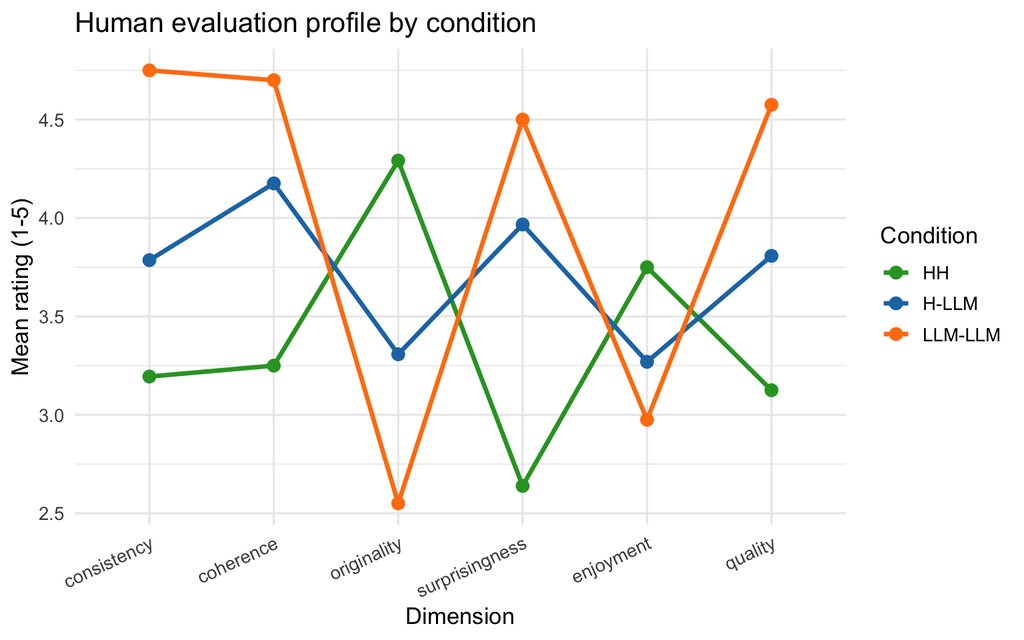

Figure 1: Figure 1: Mean Human Evaluation Ratings across Evaluative Dimensions

```r
df_story %>%
  filter(!is.na(overall)) %>%
  pivot_longer(all_of(dims), names_to = "Dimension", values_to = "Rating") %>%
  mutate(Dimension = factor(Dimension, levels = dims)) %>%
  group_by(cond, Dimension) %>%
  summarise(Mean_Rating = mean(Rating, na.rm = TRUE), .groups = "drop") %>%
  ggplot(aes(Dimension, Mean_Rating, color = cond, group = cond)) +
  geom_line(linewidth = 1.2) + geom_point(size = 3) +
  scale_color_manual(values = condition_colors) +
  labs(y = "Mean rating (1-5)", color = "Condition",
       title = "Human evaluation profile by condition") +
  theme(axis.text.x = element_text(angle = 25, hjust = 1))
```

### 8.2 Surprisal NTR Distributions across Conditions

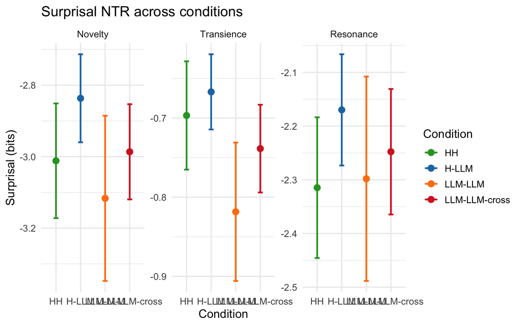

Figure 2: Figure 2: Surprisal Novelty, Transience, and Resonance across Collaborative Conditions

```r
df_story %>%
  pivot_longer(all_of(surp_cols), names_to = "Metric", values_to = "Value") %>%
  mutate(Metric = factor(Metric, levels = surp_cols,
                         labels = c("Novelty", "Transience", "Resonance"))) %>%
  group_by(cond, Metric) %>%
  summarise(Mean = mean(Value, na.rm = TRUE),
             SE = sd(Value, na.rm = TRUE) / sqrt(n()), .groups = "drop") %>%
  ggplot(aes(cond, Mean, color = cond)) +
  geom_point(size = 3) +
  geom_errorbar(aes(ymin = Mean - 1.96 * SE, ymax = Mean + 1.96 * SE),
                width = 0.2, linewidth = 0.9) +
  facet_wrap(~ Metric, scales = "free_y") +
  scale_color_manual(values = condition_colors) +
  labs(x = "Condition", y = "Surprisal (bits)", color = "Condition",
       title = "Surprisal NTR across conditions")
```

### 8.3 Within-Story Innovation Bias (Primary Estimand)

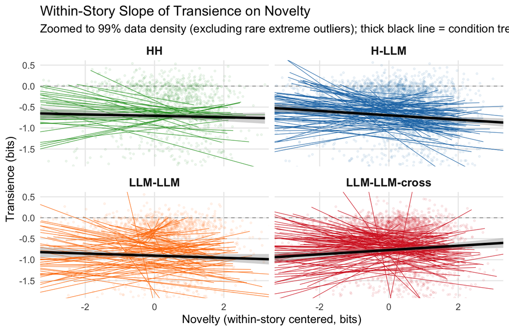

Figure 3: Figure 3: Within-Story Transience vs. Within-Story Novelty across Conditions

```r
ggplot(df_win, aes(nov_within, s_transience, color = cond)) +
  geom_hline(yintercept = 0, linetype = "dashed", color = "grey60", linewidth = 0.4) +
  geom_point(alpha = 0.08, size = 0.8) +
  geom_smooth(aes(group = id), method = "lm", se = FALSE,
              linewidth = 0.25, alpha = 0.25) +
  geom_smooth(method = "lm", se = TRUE, linewidth = 1.3, color = "black") +
  facet_wrap(~ cond, ncol = 2) +
  scale_color_manual(values = condition_colors, guide = "none") +
  coord_cartesian(xlim = c(-3.0, 3.0), ylim = c(-1.8, 0.5)) +
  labs(
    title = "Within-Story Slope of Transience on Novelty",
    subtitle = "Zoomed to 99% data density (excluding rare extreme outliers); thick black line = condition trend",
    x = "Novelty (within-story centered, bits)",
    y = "Transience (bits)"
  ) +
  theme_minimal(base_size = 13) +
  theme(
    strip.text = element_text(face = "bold", size = 13),
    panel.grid.minor = element_blank()
  )
```

**Interpretation of Figure 3**: This four-panel figure visualizes the true target estimand of the mixed-effects models: - **Visual Scaling & Density Zoom**: Because a tiny fraction ($<1\%$) of sentences exhibit extreme outlier values down to $-33$ bits (e.g. rare idiosyncratic vocabulary), the viewport is focused on the central 99% empirical data density ($\text{Novelty} \in [-3, 3]$, $\text{Transience} \in [-1.8, 0.5]$) using `coord_cartesian()`. This prevents extreme outliers from squashing the vertical scale, allowing the actual slope differences to be clearly resolved by the eye. - **Individual Story Trajectories (Thin Colored Lines)**: Each thin line represents the empirical regression line for a single story’s internal sentences. - **Condition Slope Contrasts (Thick Black Lines)**: - In `H-LLM`, the thick black line tilts visibly **downwards** ($\beta_{\text{tra}} = -0.0233$). Because $\beta_{\text{res}} = 1 - \beta_{\text{tra}}$, this negative slope produces an **innovation bias slope $> 1.0$** ($\beta_{\text{res}} = 1.023$). When an author introduces an unexpected element, the narrative subsequently preserves and incorporates it. - In `HH` and `LLM-LLM`, the slope is nearly flat ($\beta_{\text{tra}} \approx 0 \implies \beta_{\text{res}} \approx 1.0$). - In `LLM-LLM-cross` (bottom-right), the thick black line tilts visibly **upwards** ($\beta_{\text{tra}} = +0.0921, p = 0.0004$ vs `LLM-LLM`). In cross-architecture dyads, unexpected narrative elements are shed more rapidly in subsequent text, demonstrating an inter-agent uptake failure between distinct language models.

### 8.4 Diagnostic: Story-Level Association (Ecological Fallacy)

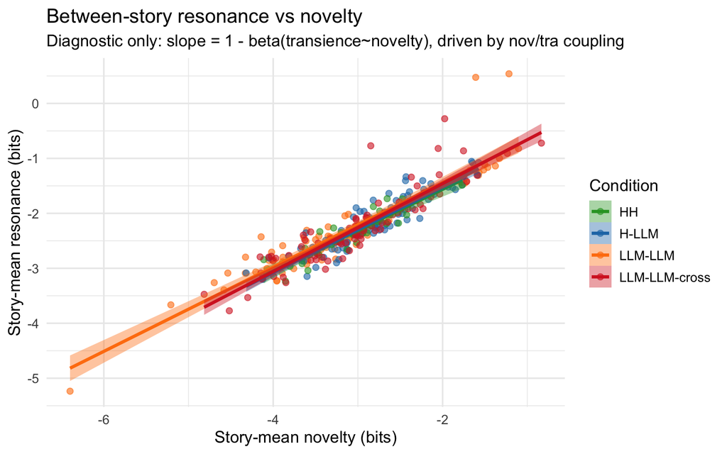

Figure 4: Figure 4: Between-Story Resonance vs. Novelty (Diagnostic Only)

```r
ggplot(df_story, aes(s_novelty, s_resonance, color = cond, fill = cond)) +
  geom_point(alpha = 0.6, size = 2) +
  geom_smooth(method = "lm", se = TRUE, linewidth = 1.2) +
  scale_color_manual(values = condition_colors) +
  scale_fill_manual(values = condition_colors) +
  labs(x = "Story-mean novelty (bits)", y = "Story-mean resonance (bits)",
       color = "Condition", fill = "Condition",
       title = "Between-story resonance vs novelty",
       subtitle = "Diagnostic only: slope = 1 - beta(transience~novelty), driven by nov/tra coupling")
```